# Analysis

This comes from the file `content/analysis.Rmd`.

We describe here our detailed data analysis.

```r
library(tidyverse)
print(getwd())
```

```
## [1] "/Users/sarazheng/Desktop/MA415/ma4615-fa22-final-project-ma415_4444/content"
```

```r
load(here::here("dataset-ignore/clean_wage.RData"))
print(ls())
```

```
## [1] "clean_wage"
```

## Motivation

As senior students, we often question ourselves about what we are doing right now. What those 22 years of education could bring us in the future? Money? Fame? We want to be rich but we don’t know if all those years of hard-work could lead to a rich life. Therefore, we want to explore the relationship between wage and education.

We also noticed that sexism is a huge issue in society, especially when it comes to wage. So we are also interested in the factors that result in the wage difference in terms of gender.

Along the way of exploration, we discovered some interesting variables that may also influence the wage. So we’re going to build models to predict wages based on those variables.

## Breadth and depth of data analysis

We are interested in the relationship between wage and variables including education, sex, age, family size, weeks worked last year, English-speaking ability, marital status, ownership of bathtub or shower, and region.

The questions are trying to answer are: 1. What factors are significant to predict one’s wage? 2. How does gender influence the performance of some variables toward wage?

## Full Model

We aim to build a model that can be used to predict wage. The independent variables we are interested in are education, sex, age, family size, weeks worked last year, english-speaking ability, marital status, ownership of bathtub or shower, and region.

### Raw Model

We run the model1 with all variables above included.

```r
#creating the factor variables

#EDUC.f
clean_wage$EDUC.f <- factor(clean_wage$EDUC)
is.factor(clean_wage$EDUC.f )
```

```
## [1] TRUE
```

```r
clean_wage$EDUC_new.f <- factor(clean_wage$EDUC_new)
is.factor(clean_wage$EDUC_new.f )
```

```
## [1] TRUE
```

```r
#SEX.f
clean_wage$SEX.f <- factor(clean_wage$SEX)
is.factor(clean_wage$SEX.f)
```

```
## [1] TRUE
```

```r
#MARST.f
clean_wage$MARST.f <- factor(clean_wage$MARST)
is.factor(clean_wage$MARST.f)
```

```
## [1] TRUE
```

```r
#SPEAKENG.f
clean_wage$SPEAKENG_new.f <- factor(clean_wage$SPEAKENG_new)
is.factor(clean_wage$SPEAKENG_new.f)
```

```
## [1] TRUE
```

```r
#STATE.f
clean_wage$STATE.f <- factor(clean_wage$STATE)
is.factor(clean_wage$STATE.f )
```

```
## [1] TRUE
```

```r
suppressPackageStartupMessages(library(tidyverse))
lm_mod1 <-lm(INCWAGE ~ EDUC.f + SEX.f + MARST.f + SPEAKENG_new.f + STATE.f + FAMSIZE + WKSWORK1 + AGE + SHOWER, data = clean_wage)

broom::tidy(lm_mod1) %>%
  select(term, estimate, p.value) %>%
  mutate(across(where(is.numeric), ~round(., 5))) %>%
  DT::datatable()
```

|  | term | estimate | p.value |
| --- | --- | --- | --- |
| 1 | (Intercept) | -7747.57468 | 0 |
| 2 | EDUC.f1 | -343.24909 | 0.15085 |
| 3 | EDUC.f2 | -445.18926 | 0.00203 |
| 4 | EDUC.f3 | 116.90283 | 0.45691 |
| 5 | EDUC.f4 | 249.27784 | 0.07619 |
| 6 | EDUC.f5 | -979.30686 | 0 |
| 7 | EDUC.f6 | 554.7851 | 0 |
| 8 | EDUC.f7 | 1533.35683 | 0 |
| 9 | EDUC.f8 | 4529.24133 | 0 |
| 10 | EDUC.f10 | 9482.36371 | 0 |

[output cut: 56 more lines]

### Final Model

```r
suppressPackageStartupMessages(library(tidyverse))
lm_mod2 <-lm(INCWAGE ~ EDUC.f + SEX.f + MARST.f + SPEAKENG_new.f + FAMSIZE + WKSWORK1 + AGE + SHOWER, data = clean_wage)

broom::tidy(lm_mod2) %>%
  select(term, estimate, p.value) %>%
  mutate(across(where(is.numeric), ~round(.,))) %>%
  DT::datatable()
```

|  | term | estimate | p.value |
| --- | --- | --- | --- |
| 1 | (Intercept) | -6077 | 0 |
| 2 | EDUC.f1 | -381 | 0 |
| 3 | EDUC.f2 | -631 | 0 |
| 4 | EDUC.f3 | -199 | 0 |
| 5 | EDUC.f4 | -44 | 1 |
| 6 | EDUC.f5 | -1209 | 0 |
| 7 | EDUC.f6 | 373 | 0 |
| 8 | EDUC.f7 | 1347 | 0 |
| 9 | EDUC.f8 | 4390 | 0 |
| 10 | EDUC.f10 | 9472 | 0 |

[output cut: 8 more lines]

Interpretation based on coefficients: Education: there’s a turning point at grade 12 (06), negative relationship before grade 12, then positive relationship after grade 12. Gender: the average wage of females is $4121 lower than males per year. Marriage status: marriage’s wage is $3870 higher than non-marriage per year. English speaking: dummy variable error Family size: negative relationship $-279 per year Weeks work last year: positive relationship $773 per year

### Coefficient Breakdown

#### wage ~ education

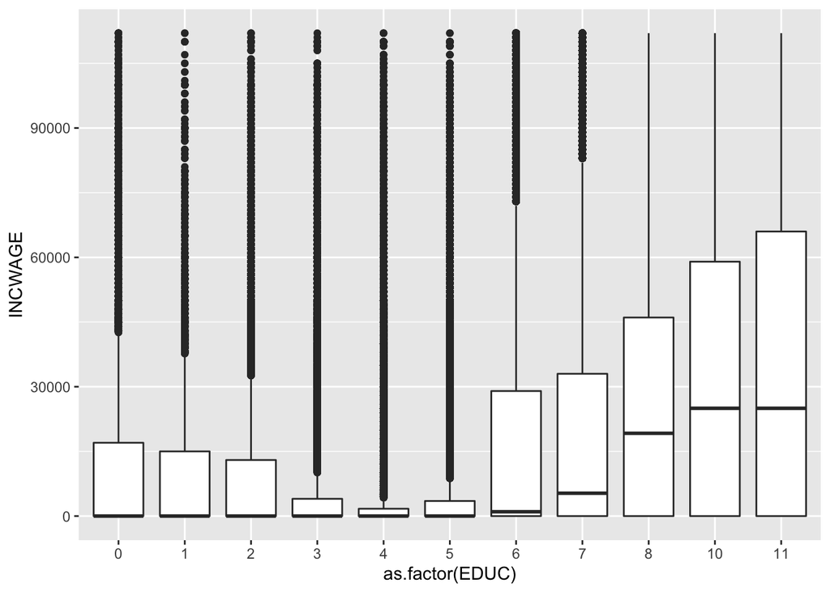

```r
#relationship between wage and education
clean_wage %>%
ggplot(aes(x = as.factor(EDUC), y = INCWAGE)) + geom_boxplot()
```

##### wage ~ education (by sex)

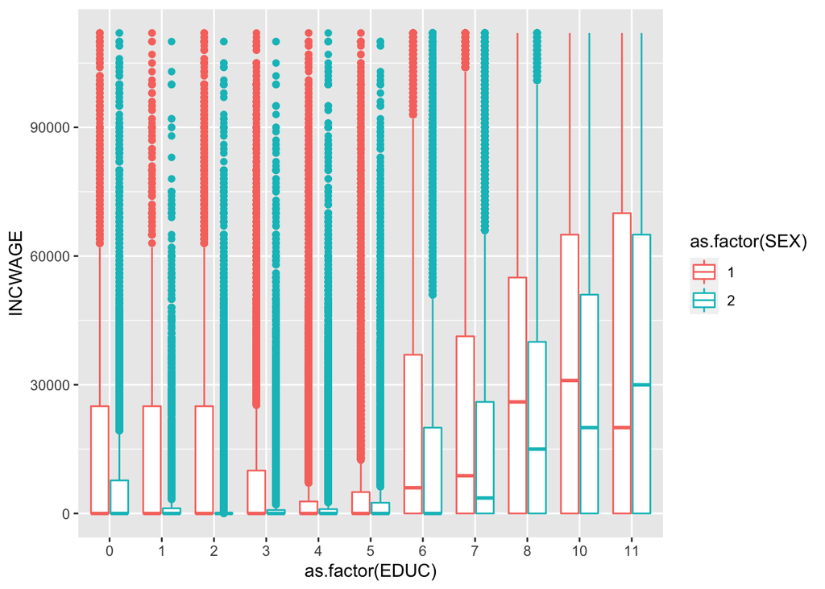

```r
#relationship between wage and education colored by gender
clean_wage %>%
ggplot(aes(x = as.factor(EDUC), y = INCWAGE, color=as.factor(SEX))) + geom_boxplot()
```

```r
male_data <- clean_wage %>%
  filter(SEX==1)

female_data <- clean_wage %>%
  filter(SEX==2)
```

```r
suppressPackageStartupMessages(library(tidyverse))
lm_educ_male <-lm(INCWAGE ~ as.factor(EDUC), data = male_data)

broom::tidy(lm_educ_male) %>%
  select(term, estimate, p.value) %>%
  mutate(across(where(is.numeric), ~round(.,))) %>%
  DT::datatable()
```

|  | term | estimate | p.value |
| --- | --- | --- | --- |
| 1 | (Intercept) | 14047 | 0 |
| 2 | as.factor(EDUC)1 | -627 | 0 |
| 3 | as.factor(EDUC)2 | -832 | 0 |
| 4 | as.factor(EDUC)3 | -4492 | 0 |
| 5 | as.factor(EDUC)4 | -7145 | 0 |
| 6 | as.factor(EDUC)5 | -6623 | 0 |
| 7 | as.factor(EDUC)6 | 6745 | 0 |
| 8 | as.factor(EDUC)7 | 9451 | 0 |
| 9 | as.factor(EDUC)8 | 17891 | 0 |
| 10 | as.factor(EDUC)10 | 22753 | 0 |

[output cut: 1 more lines]

```r
suppressPackageStartupMessages(library(tidyverse))
lm_educ_female <-lm(INCWAGE ~ as.factor(EDUC), data = female_data)

broom::tidy(lm_educ_female) %>%
  select(term, estimate, p.value) %>%
  mutate(across(where(is.numeric), ~round(.,))) %>%
  DT::datatable()
```

|  | term | estimate | p.value |
| --- | --- | --- | --- |
| 1 | (Intercept) | 7385 | 0 |
| 2 | as.factor(EDUC)1 | -1488 | 0 |
| 3 | as.factor(EDUC)2 | -2220 | 0 |
| 4 | as.factor(EDUC)3 | -2655 | 0 |
| 5 | as.factor(EDUC)4 | -3869 | 0 |
| 6 | as.factor(EDUC)5 | -3275 | 0 |
| 7 | as.factor(EDUC)6 | 4535 | 0 |
| 8 | as.factor(EDUC)7 | 8227 | 0 |
| 9 | as.factor(EDUC)8 | 15555 | 0 |
| 10 | as.factor(EDUC)10 | 21813 | 0 |

[output cut: 1 more lines]

#### wage ~ age (by sex)

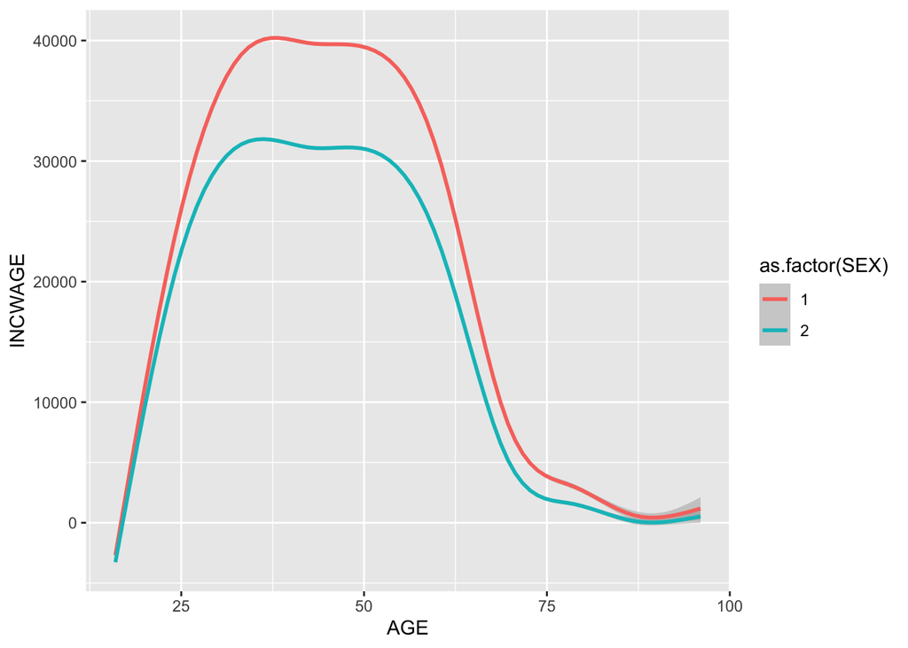

```r
#relationship between wage and education colored by gender
clean_wage %>%
ggplot(aes(x = AGE, y = INCWAGE, color=as.factor(SEX))) + geom_smooth()
```

#### wage ~ marital status (by sex)

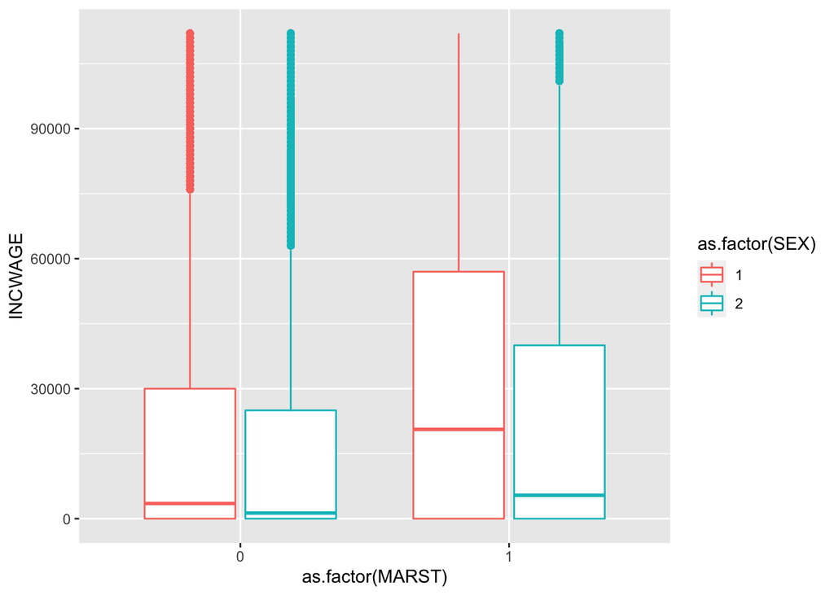

```r
clean_wage %>%
ggplot(aes(x = as.factor(MARST), y = INCWAGE, color=as.factor(SEX))) + geom_boxplot()
```

## Note on Attribution

If you are directly quoting from a source, please make that clear. You can show quotes using `>` like this

```
> To be or not to be.
```

> To be or not to be.

Also, make sure to provide a link or citation to where you are quoting from.

## Rubric: On this page

you will

- Introduce what motivates your Data Analysis (DA)
  - Which variables and relationships are you most interested in?

```r
#the relationship between wage and education.
#what factors can influence one's wage and salary
```

- What questions are you interested in answering?

```r
#relationship between wage and education
```

- Breadth of the DA
  - Make sure that you ask enough initial questions to explore the different variables in your data.
  - i.e. Do you explore more than just one or two variables? Do you explore a few different relationships or many?

```r
#relationship between wage and education colored by gender
```

**NOTE**: Your Data Analysis can be broken up into multiple pages if that helps with your organization.